# MATH1062 Stats Note

back04oorer

2024-11-06

# 1 DATA&Graphical Summaries

## 1.1 Read In Data

**header = TRUE**: The first row is treated as the **header row**, and the values in that row are used as column names.

**header = FALSE**: If you set header = FALSE, R will treat the first row as **regular data** and not as column names. In this case, R will automatically assign default column names such as V1, V2, V3, …

```r
data = read.csv("data/2023fatalities.csv", header = TRUE)
```

## 1.2 Initial data analysis (IDA)

### 1.2.1 Definition

Data is **informaion** about the set of subjects being studied (like road fatalities). Most commonly, data refers to the **sample**, not the population.

**Initial data analysis** is a first general look at the data, without formally answering the research questions.

- IDA helps you to see whether the data can answer your research questions
- IDA may pose other research questions
- IDA can
  - identify the data’s main qualities
  - suggest the population from which a sample derives

### 1.2.2 IDA commonly involves

Initial Data Analysis commonly involves:

- data background: checking the quality and integrity of the data
- data structure: what information has been collected?
- data wrangling: scraping, cleaning, tidying, reshaping, splitting, combining
- data summaries: graphical and numerical

## 1.3 Identifying variables

### 1.3.1 Number of variables

| 1 variables | 2 variables | 2+ variables |
| --- | --- | --- |
| Univariate | Bivariate | Multivariate |

### 1.3.2 Types of variables

- **Qualitative or Categorical (Categories)**
  - **IN R: Factor or Character**
  - **Ordinal (ordered)**
    - Binary (2 categories)
    - 3+ categories
  - **Nominal (non-ordered)**
    - Binary (2 categories)
    - 3+ categories
- **Quantitative or Numerical (Measurements)**
  - **IN R: Numeric**
  - **Discrete**
    - R: Integer (int)
    - Binary (2 categories)
    - 3+ categories
  - **Continuous**
    - R: Double

### 1.3.3 Change variable types in R

**Structure of Data**

```r
str(data, vec.len = 2)
```

```
## 'data.frame':    55360 obs. of  24 variables:
##  $ Crash.ID                     : int  20237008 20234009 20233087 20233149 20233190 ...
##  $ State                        : chr  "NT" "SA" ...
##  $ Month                        : int  10 10 10 10 10 ...
##  $ Year                         : int  2023 2023 2023 2023 2023 ...
##  $ Dayweek                      : chr  "Friday" "Saturday" ...
##  $ Time                         : chr  "" "03:00" ...
##  $ Crash.Type                   : chr  "Single" "Single" ...
##  $ Bus.Involvement              : chr  "No" "No" ...
##  $ Heavy.Rigid.Truck.Involvement: chr  "No" "No" ...
##  $ Articulated.Truck.Involvement: chr  "No" "No" ...
##  $ Speed.Limit                  : chr  "-9" "100" ...
##  $ Road.User                    : chr  "Driver" "Driver" ...
##  $ Gender                       : chr  "Female" "Male" ...
##  $ Age                          : int  24 22 19 37 35 ...
##  $ National.Remoteness.Areas    : chr  "" "Outer Regional Australia" ...
##  $ SA4.Name.2021                : chr  "" "Barossa - Yorke - Mid North" ...
##  $ National.LGA.Name.2021       : chr  "" "Yorke Peninsula" ...
##  $ National.Road.Type           : chr  "" "Local Road" ...
##  $ Christmas.Period             : chr  "No" "No" ...
##  $ Easter.Period                : chr  "No" "No" ...
##  $ Age.Group                    : chr  "17_to_25" "17_to_25" ...
##  $ Day.of.week                  : chr  "Weekend" "Weekend" ...
##  $ Time.of.day                  : chr  "Night" "Night" ...
##  $ X                            : logi  NA NA NA ...
```

**From Numerical to Categorical**

```r
# Change type of Variables
data$Crash.ID = as.factor(data$Crash.ID)
data$Month = as.factor(data$Month)

# 显示转化后数据的结构
# list.len 参数用于指定要显示的列表元素的最大数量。
# vec.len 参数用于指定要显示的向量元素的最大数量。
str(data, list.len = 5, vec.len = 2)
```

```
## 'data.frame':    55360 obs. of  24 variables:
##  $ Crash.ID                     : Factor w/ 49903 levels "19891001","19891002",..: 49880 49646 49506 49568 49609 ...
##  $ State                        : chr  "NT" "SA" ...
##  $ Month                        : Factor w/ 12 levels "1","2","3","4",..: 10 10 10 10 10 ...
##  $ Year                         : int  2023 2023 2023 2023 2023 ...
##  $ Dayweek                      : chr  "Friday" "Saturday" ...
##   [list output truncated]
```

**From Categorical to Numerical**

```r
data$Speed.Limit = as.numeric(data$Speed.Limit)
# New structure of Data display the 5 variables using list.len
# 第11到第15个变量
str(data[c(11, 12, 13, 14, 15)], vec.len = 2)
```

```
## 'data.frame':    55360 obs. of  5 variables:
##  $ Speed.Limit              : num  -9 100 80 60 100 ...
##  $ Road.User                : chr  "Driver" "Driver" ...
##  $ Gender                   : chr  "Female" "Male" ...
##  $ Age                      : int  24 22 19 37 35 ...
##  $ National.Remoteness.Areas: chr  "" "Outer Regional Australia" ...
```

## 1.4 Graphical summaries

这个还没教完,可以先看看

| **Variables** | **Graphical summaries** | **Numerical summaries** |
| --- | --- | --- |
| **1 Qualitative** | Bar plot | Frequency table |
|  |  | Most popular category |
| **2 Qualitative** | Stacked bar plot | Contingency table |
|  |  | Most popular category |
| **1 Quantitative** | Histogram | Mean, median, SD, IQR, range |
|  | Boxplot |  |
| **2 Quantitative** | Scatter plot | Linear model |
|  |  | Correlation coefficient |
| **1 Qualitative + 1 Quantitative** | Side by side boxplot |  |

### 1.4.1 Barplot

**Step 1: Build the frequency table**

```r
# Select the DayWeek variable from the whole data frame
Dayweek = data$Dayweek

# Produce a frequency table of fatalities per day of the week
table(Dayweek)
```

```
## Dayweek
##    Friday    Monday  Saturday    Sunday  Thursday   Tuesday Wednesday
##      9094      6382     10107      8855      7456      6483      6983
```

```r
# Order days
Dayweek = factor(Dayweek, levels = c("Monday", "Tuesday", "Wednesday", "Thursday", "Friday", "Saturday", "Sunday"))
table(Dayweek)
```

```
## Dayweek
##    Monday   Tuesday Wednesday  Thursday    Friday  Saturday    Sunday
##      6382      6483      6983      7456      9094     10107      8855
```

**Step 2: Produce the barplot**

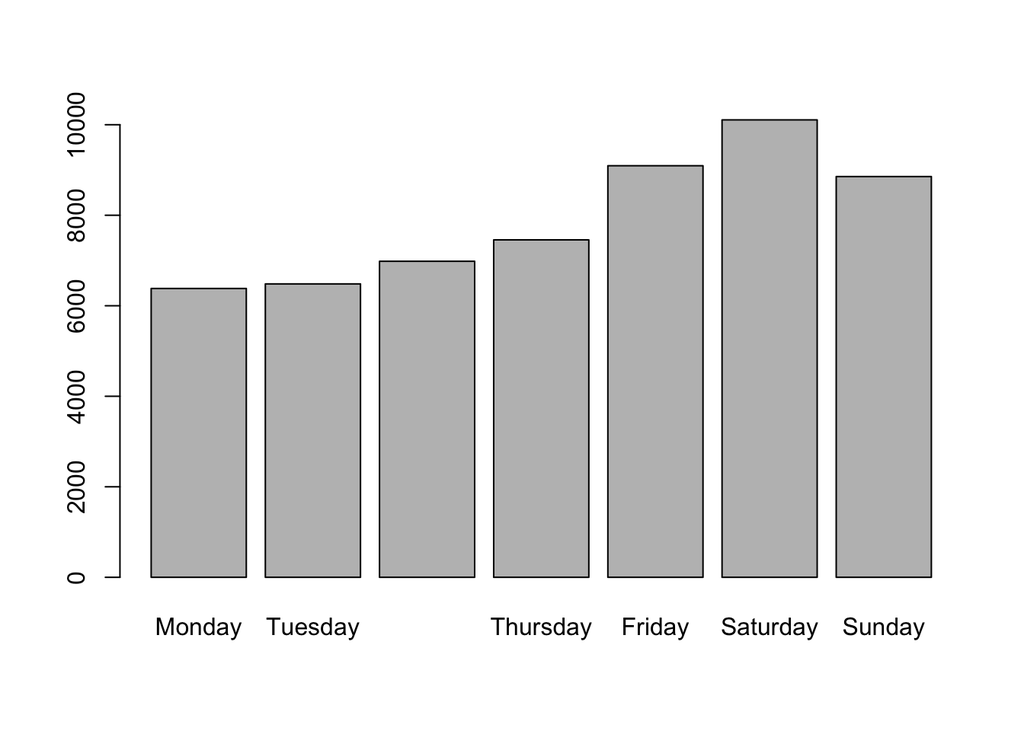

```r
barplot(table(Dayweek))
```

### 1.4.2 Double barplot

```r
# Select DayWeek and Gender variables
Dayweek = data$Dayweek
Gender = data$Gender
# Produce a double frequency table (contingency table)
data1 = table(Gender, Dayweek)
data1
```

```
##              Dayweek
## Gender        Friday Monday Saturday Sunday Thursday Tuesday Wednesday
##   -9              10      3        6      2        3       2        12
##   Female        2538   1945     2555   2325     2094    2034      2135
##   M                0      0        0      0        0       0         1
##   Male          6545   4433     7541   6528     5359    4447      4835
##   U                1      1        4      0        0       0         0
##   Unspecified      0      0        1      0        0       0         0
```

#### 1.4.2.1 Stacked barplot

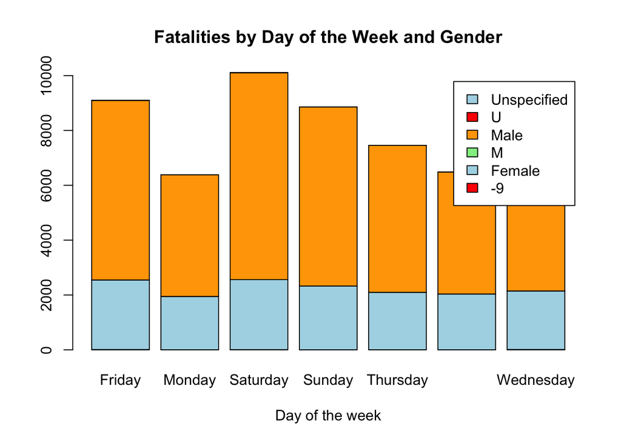

```r
barplot(data1, main = "Fatalities by Day of the Week and Gender", xlab = "Day of the week", col = c("red", "lightblue", "lightgreen", "orange"), legend = rownames(data1))
```

#### 1.4.2.2 Side-by-side barplot

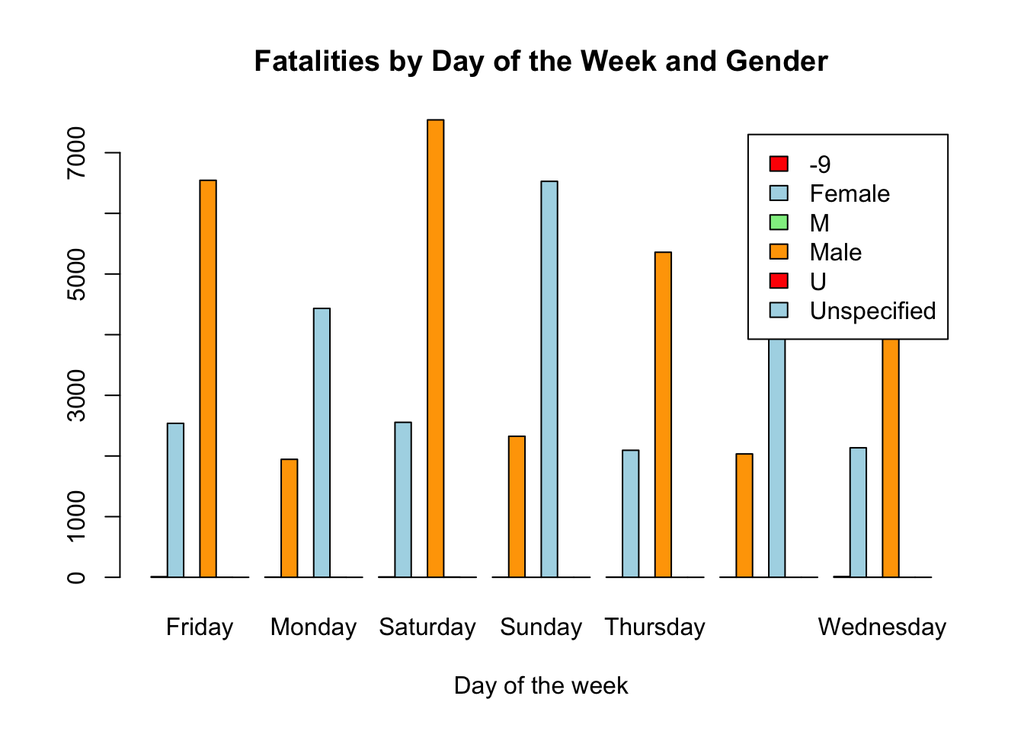

```r
barplot(data1, main = "Fatalities by Day of the Week and Gender", xlab = "Day of the week", col = c("red", "lightblue", "lightgreen", "orange"), legend = rownames(data1), beside = TRUE)
```

#### 1.4.2.3 Side-by-side barplot ignoring ‘-9’, ‘M’, ‘U’ and ’Unspecified

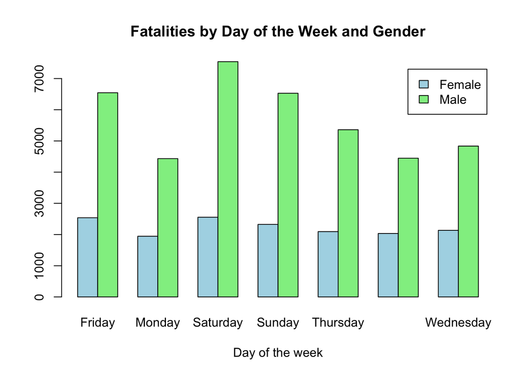

```r
barplot(data1[-c(1, 3, 5, 6), ], main = "Fatalities by Day of the Week and Gender", xlab = "Day of the week", col = c("lightblue", "lightgreen"), legend = rownames(data1[-c(1, 3, 5, 6), ]), beside = TRUE)
```

### 1.4.3 Histogram

The frequency table can also be used to summarise a set of **quantitative** data, by collecting the datq into class intervals (or ‘bins’). A histogram highlights the frequency of data in one class interval compared to another.

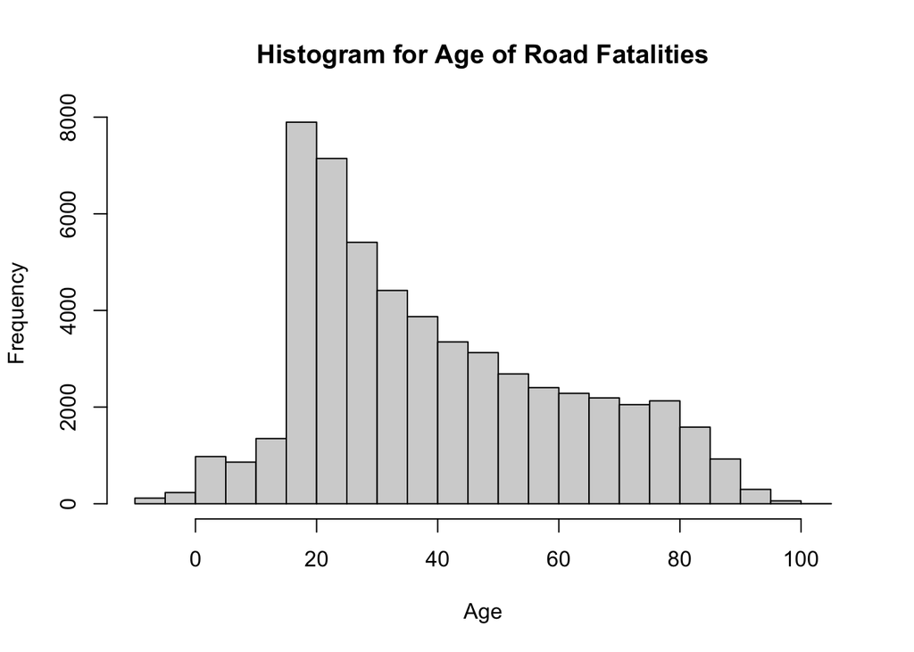

```r
hist(data$Age, xlab = "Age", ylab = "Frequency", main = "Histogram for Age of Road Fatalities")
```

```r
# Select the variable Age
Age = data$Age
# Define end points for class intervals
breaks = c(-10, 18, 25, 70, 101)
# Build frequency table
table(cut(Age, breaks, right = F))
```

```
##
## [-10,18)  [18,25)  [25,70) [70,101)
##     5747    11541    30566     7504
```

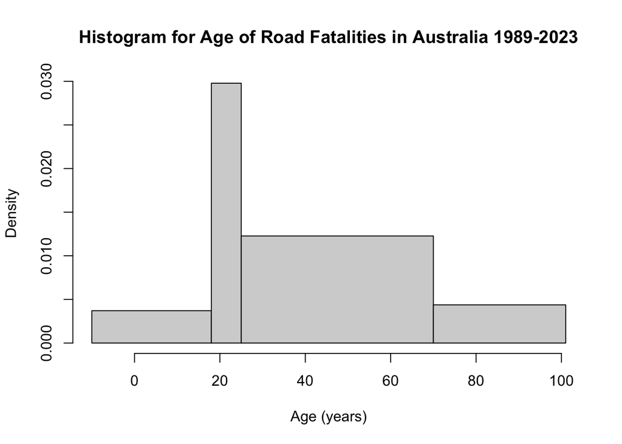

```r
hist(Age, br = breaks, right = F, freq = F, xlab = "Age (years)", ylab = "Density", main = "Histogram for Age of Road Fatalities in Australia 1989-2023")
```

The area of each block represents the proportion of subjects in that particular class interval.

#### 1.4.3.1 DATA Cleaning

It’s better to replace the ‘-9’ entries to NA

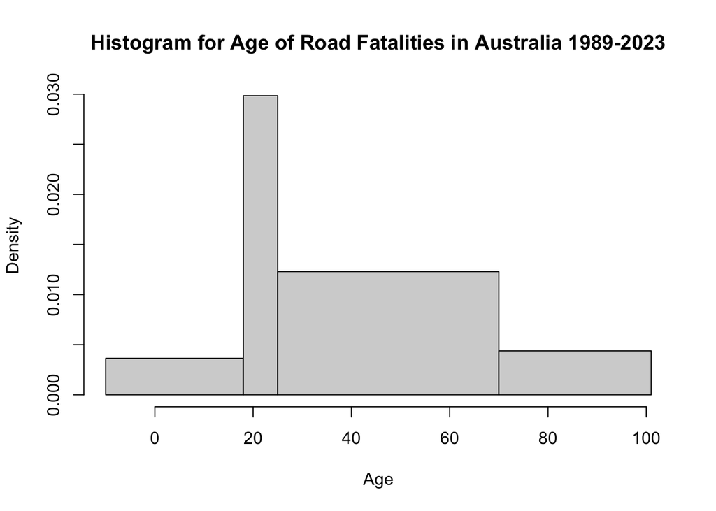

```r
# Replacing the '-9' entries
data$Age[data$Age == -9] = NA

hist(data$Age, br = breaks, freq = F, right = F, xlab = "Age", ylab = "Density", main = "Histogram for Age of Road Fatalities in Australia 1989-2023")
```

#### 1.4.3.2 Details of density-scale histograms

The area of the whole histogram on the density scale is one (or, in percentage, 100%).

**area (proportion) of each block** =

$$\frac{\text{number of subjects in the class interval}}{\text{total
number of subjects}}$$

**height (density) of each block** =

$$\frac{\text{proportion of the block}}{\text{length of the class
interval}}$$

For continuous (quantitative) data, we need an endpoint convention for data points that fall on the border of two class intervals.

Number of class intervals

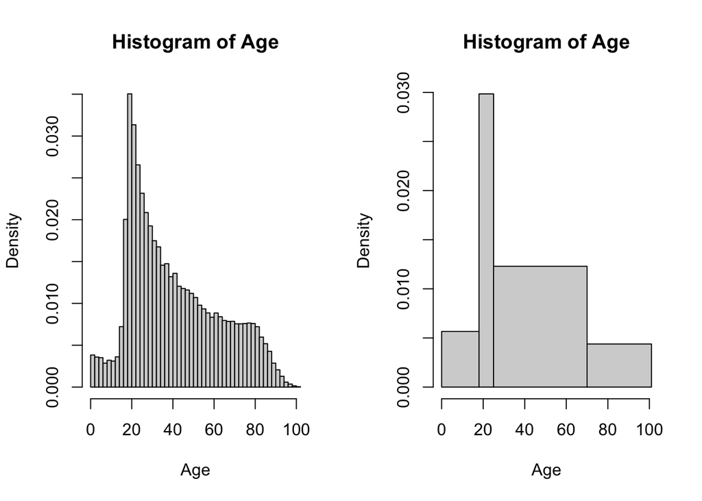

```r
Age = data$Age
par(mfrow = c(1, 2)) # This puts the graphic output in 1 row with 2 columns

breaks = seq(0, 102, 2)
hist(Age, br = breaks, freq = F, right = F, xlab = "Age", ylab = "Density")

breaks = c(0, 18, 25, 70, 101)
hist(Age, br = breaks, freq = F, right = F, xlab = "Age", ylab = "Density")
```

#### 1.4.3.3 Produce a histogram by hand

**Step 1**: Construct the distribution table.

| Class intervals | Number of subjects in the interval | % | Height of block |
| --- | --- | --- | --- |
| [0,18) | 5747 | 10.4 | 0.0058 |
| [18,25) | 11541 | 20.8 | 0.0298 |
| [25,70) | 30566 | 55.2 | 0.0123 |
| [70,101) | 7504 | 13.6 | 0.0044 |
| **Total** | **55360** | **100** |  |

**Step 2**: Draw the horizontal axis and blocks

**Quick Way In R** :

- freq=F produces the histogram on the density scale.
- right=F makes the intervals right-open

### 1.4.4 Other graphical summaries

#### 1.4.4.1 Scatter Plot

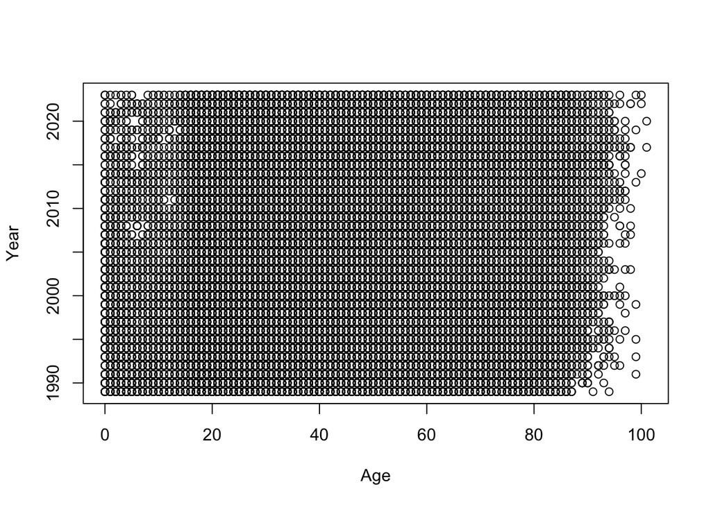

```r
#### Scatter Plot
Year = data$Year
plot(Age, Year)
```

#### 1.4.4.2 Heatmap

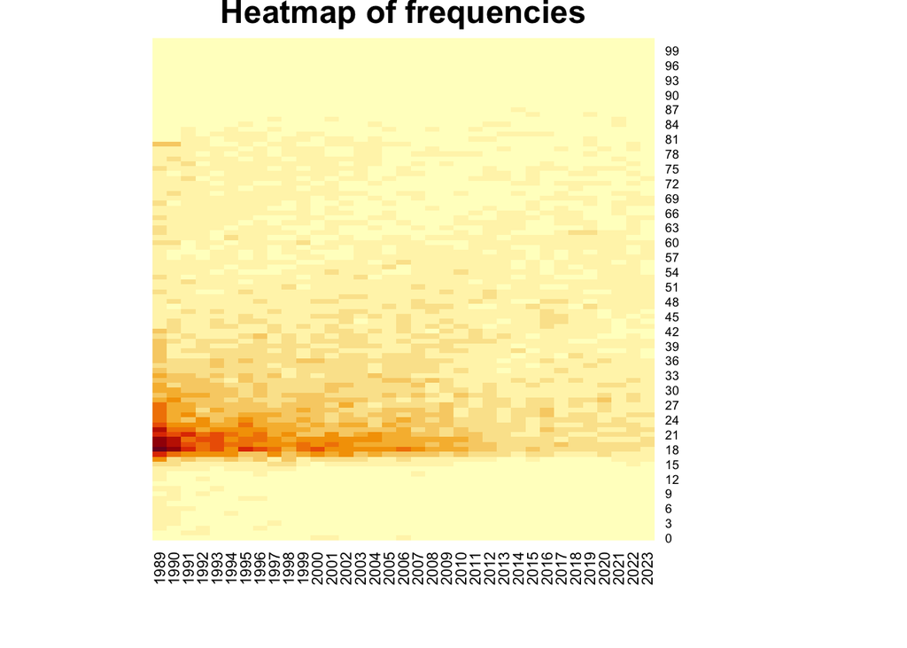

```r
heatmap(table(Age, Year), Rowv = NA, Colv = NA, scale = "none", main = "Heatmap of frequencies")
```

#### 1.4.4.3 Boxplot

```r
Age = data$Age
summary(Age)
```

```
##    Min. 1st Qu.  Median    Mean 3rd Qu.    Max.    NA's
##    0.00   22.00   35.00   39.99   56.00  101.00     116
```

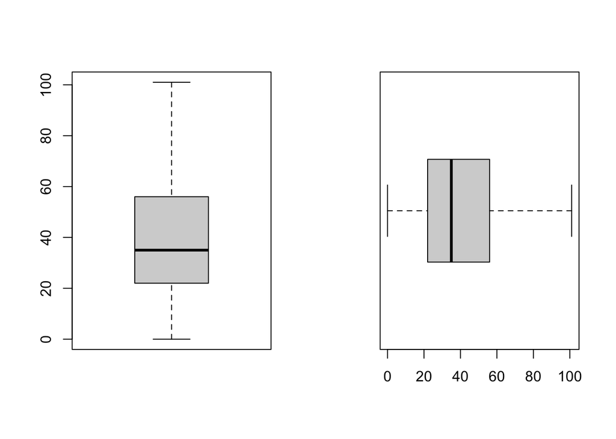

```r
par(mfrow = c(1, 2))
boxplot(Age)
boxplot(Age, horizontal = T)
```

#### 1.4.4.4 Comparitive box plots

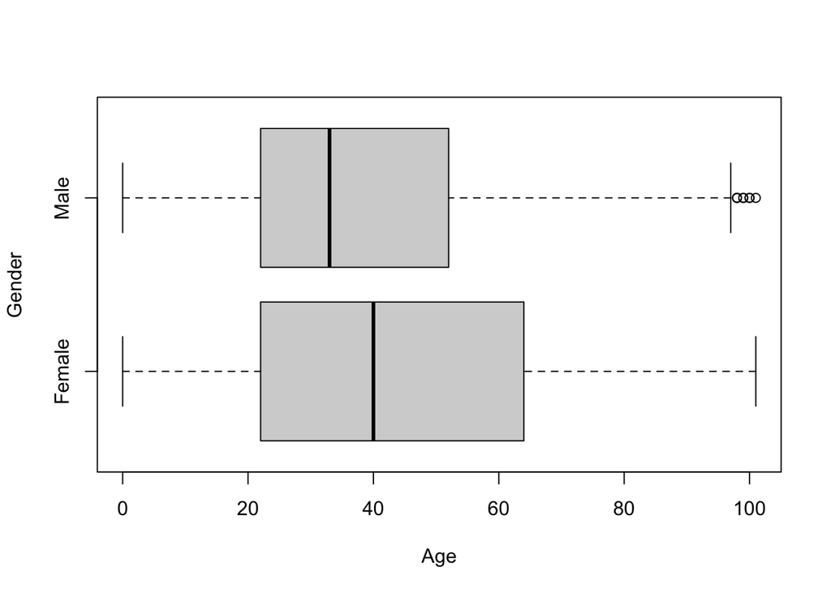

```r
data$Gender = factor(data$Gender, levels = c("Female", "Male"))
Gender = data$Gender
boxplot(Age ~ Gender, horizontal = T)
```

## 1.5 Logical operators

| Symbol | Description |
| --- | --- |
| `>` | greater than |
| `>=` | greater than or equal to |
| `<` | less than |
| `<=` | less than or equal to |
| `==` | equal to |
| `!=` | not equal to |

# 2 Numerical Summaries

## 2.1 Import Data

```r
data = read.csv("data/NewtownJune2017.csv",header=T)
str(data)
```

```
## 'data.frame':    56 obs. of  8 variables:
##  $ Property : chr  "19 Watkin Street Newtown" "30 Pearl Street Newtown" "26 John Street Newtowmn" "23/617-623 King Street Newtown" ...
##  $ Type     : chr  "House" "House" "House" "Apartment" ...
##  $ Agent    : chr  "RayWhite" "RayWhite" "Belle" "RayWhite" ...
##  $ Bedrooms : int  4 2 2 1 1 5 1 1 1 3 ...
##  $ Bathrooms: int  1 1 1 1 1 1 1 1 1 2 ...
##  $ Carspots : int  1 0 0 1 1 1 0 1 1 0 ...
##  $ Sold     : int  1975 1250 1280 780 650 2100 675 740 625 1950 ...
##  $ Date     : chr  "23/6/17" "23/6/17" "17/6/17" "17/6/17" ...
```

## 2.2 Notations

Observations of a single variable of size $n$ can be represented by

$x_1, x_2, \dots, x_n$

The ranked observations (ordered from smallest to largest) are

$x_{(1)}, x_{(2)}, \dots, x_{(n)}$

such that $x_{(1)} \leq x_{(2)} \leq \dots \leq x_{(n)}$

The sum of the observations is

$$\sum_{i=1}^{n} x_i$$

## 2.3 Numerical Summaries Intro

A numerical summary reduces all the data to one simple number (“statistic”).

- This loses a lot of information
- However it allows easy communication and comparisons.

**Major features** that we can summarise numerically are:

- Maximum
- Minimum
- Centre[sample mean,median]
- Spread[standard deviation,range,interquartile range]

## 2.4 Centre

### 2.4.1 Sample Mean

The sample mean is the **average** of the data.

$$\text{sample mean} = \frac{\text{sum of data}}{\text{size of data}}$$

or

$$\bar{x} = \frac{\sum_{i=1}^{n} x_i}{n}$$

### 2.4.2 Deviation from the mean

Given a data point $x_i$, its deviation from the sample mean $\bar{x}$ is

$$D_i = x_i - \bar{x}$$

### 2.4.3 Sample mean as a balancing point

The sample mean is the point at which the data is **balanced** in the sense the sum of the **absolute deviations** for values to the left of the mean is the same as the sum of absolute deviations to the right of the mean.

$$\sum_{x_i < \bar{x}} |x_i - \bar{x}| = \sum_{x_i > \bar{x}} |x_i -
\bar{x}|$$

### 2.4.4 Sample mean on the histogram

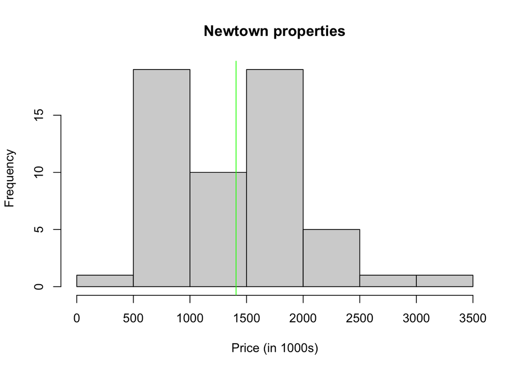

```r
hist(data$Sold, main="Newtown properties", xlab="Price (in 1000s)")

abline(v=mean(data$Sold),col="green")
```

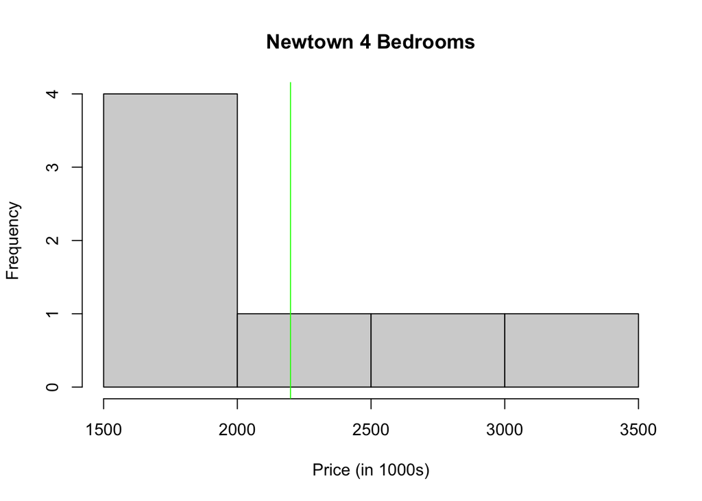

```r
hist(data$Sold[data$Type=="House" & data$Bedrooms=="4"], main="Newtown 4 Bedrooms", xlab="Price (in 1000s)" )

abline(v=mean(data$Sold[data$Type=="House" & data$Bedrooms=="4"]),col="green")
```

### 2.4.5 Sample median

The sample median $\tilde{x}$ is the **middle data point**, when the observations are ordered from smallest to largest.

- For an odd-sized number of observations:

  $$\text{sample median} = \text{the unique middle point} =
  x_{\left(\frac{n+1}{2}\right)}$$
- For an even-sized number of observations:

  $$\text{sample median} = \text{average of the 2 middle points} =
  \frac{x_{\left(\frac{n}{2}\right)} + x_{\left(\frac{n}{2}+1\right)}}{2}$$

### 2.4.6 Sample Median In R

(i)Sort and Observe

```r
sort(data$Sold)
```

```
##  [1]  370  625  645  650  675  692  720  740  740  755  770  780  812  860  861
## [16]  920  935  955  955  999 1100 1240 1250 1280 1309 1315 1370 1375 1400 1460
## [31] 1553 1575 1590 1600 1600 1600 1605 1662 1701 1710 1750 1780 1790 1806 1850
## [46] 1940 1950 1975 2000 2100 2200 2235 2300 2410 2810 3150
```

```r
length(data$Sold)
```

```
## [1] 56
```

(28th + 29th)/2 = 1387.5

(ii)Directly use function `median()`

```r
median(data$Sold)
```

```
## [1] 1387.5
```

### 2.4.7 Sample median on the histogram

The sample median is the **half way point** on the histogram - i.e., 50% of the houses sold are below and above $1.3875 million.

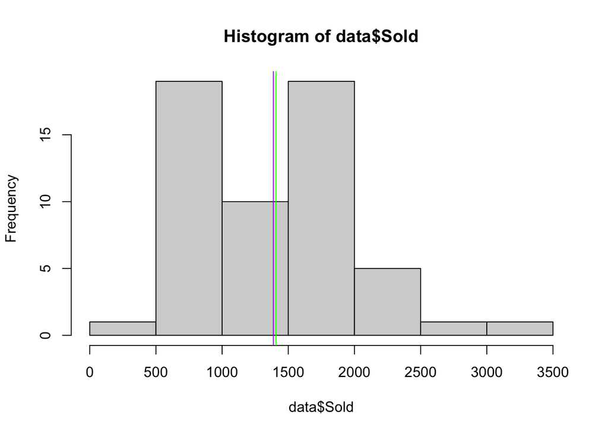

```r
hist(data$Sold)
abline(v=mean(data$Sold),col="green")
abline(v=median(data$Sold),col="purple")
```

### 2.4.8 Sample mean and median on the boxplot

**The sample median is the centre line on the boxplot.**

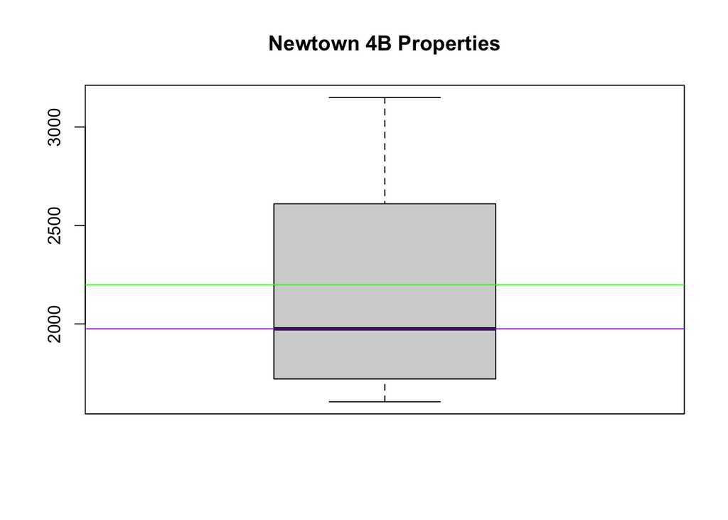

```r
boxplot(data$Sold[data$Type=="House" & data$Bedrooms=="4"], main = "Newtown 4B Properties")

abline(h=mean(data$Sold[data$Type=="House" & data$Bedrooms=="4"]),col="green")

abline(h=median(data$Sold[data$Type=="House" & data$Bedrooms=="4"]),col="purple")
```

## 2.5 Robustness

### 2.5.1 Sample Mean vs Median

The difference between the sample mean and the sample median can be an indication of the **shape** of the data.

- For symmetric data, the sample mean and sample median are the same: $\bar{x} = \tilde{x}$.
- For left skewed data (the most frequent data are concentrated on the right, with a left tail), the sample mean is smaller than the sample median: $\bar{x} < \tilde{x}$.
- For right skewed data (the most frequent data are concentrated on the left, with a right tail), the sample mean is larger than the sample median: $\bar{x} > \tilde{x}$.

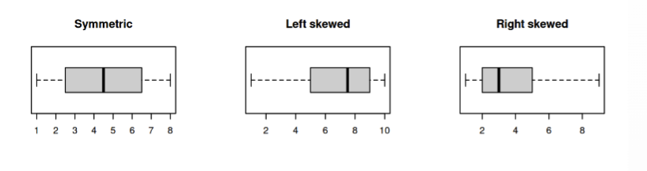

### 2.5.2 Optimal Choice

- As the **sample median is robust**, it is preferable for data which is skewed or has many outliers.
- The sample mean is helpful for data which is **basically symmetric**, with not too many outliers, and for theoretical analysis.

## 2.6 Spread

### 2.6.1 Standard deviation (SD)

**Root mean square (RMS)**

$$\text{RMS(numbers)} = \sqrt{\text{sample
mean}\left(\text{numbers}^2\right)}$$

The standard deviation measures the **spread** of the data.

$$\text{SD}_{\text{pop}} = \text{RMS of (deviations from the mean)}$$

Formally,

$$\text{SD}_{\text{pop}} = \sqrt{\text{Mean of (deviations from the
mean)}^2} = \sqrt{\frac{\sum_{i=1}^{n} (x_i - \bar{x})^2}{n}}$$

### 2.6.2 Sd_pop vs Sd_sample

There are **two** different formulas for the standard deviation, depending on whether the data is the **population** or a **sample**.

The `sd` command in R always gives the **sample** version, as we most commonly have samples.

Formally,

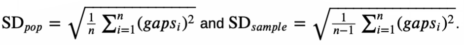

| Summary | Formula | In R |
| --- | --- | --- |
| **Population or Sample mean** | Sample Mean (Average) | `mean(data)` |
| **Population standard deviation** | RMS of gaps from the sample mean | `sd(data) * sqrt((n-1)/n)` |
| **Sample standard deviation** | Adjusted RMS of gaps from the sample mean | `sd(data)` |

The squared standard deviation is called the **variance**: $\text{SD}^2$.

The population standard deviation is always smaller than a sample standard deviation, $\text{SD}_{\text{pop}} \leq \text{SD}_{\text{sample}}$, why? Extra variability due to sampling.

*Note*: **For large sample sizes, the difference becomes negligible**

### 2.6.3 Population data or Sample data ?

If we are just interested in the Newtown property prices during April-June 2017, then the `data` is the whole population.

If we are studying the property prices during April-June 2017 as a **window into more general property prices** (for the rest of the year or for the Inner West area) , then the data could be considered a sample

### 2.6.4 Standard Units (Z-score)

**Standard units of a data point** = how many standard deviations is it below or above the mean

$$\text{standard units} = \frac{\text{data point} -
\text{mean}}{\text{SD}}$$

This means that

$$\text{data point} = \text{mean} + \text{SD} \times \text{standard units}$$

It gives the relative location of a data point in the data set. It also has other benefits in data modelling (see later lectures).

### 2.6.5 Interquartile range

**IQR** = range of the middle 50% of the data

- More formally, **IQR** = $Q_3 - Q_1$, where
  - $Q_1$ is the 25% percentile (1st quartile) and $Q_3$ is the 75% percentile (3rd quartile).
  - The median is the 50% percentile, or 2nd quartile $\tilde{x} = Q_2$.

### 2.6.6 Quantile, quartile, percentile

The set of **q-quantiles** divides the ordered data into equal size sets (in terms of percentage of data).

- **quartiles**: If q = 4, then the data set will be divided into 4 equal parts, each representing 25% of data.
- If q = 100, the data is divided into 100 equal parts, each containing 1% of the data. These are known as **percentiles**.

```r
summary(data$Sold)
```

```
##    Min. 1st Qu.  Median    Mean 3rd Qu.    Max.
##   370.0   860.8  1387.5  1407.1  1782.5  3150.0
```

```r
summary(data$Sold)[5] - summary(data$Sold)[2] # one way to calculate IQR
```

```
## 3rd Qu.
##  921.75
```

```r
IQR(data$Sold)
```

```
## [1] 921.75
```

- IDR is **robust**

### 2.6.7 IQR on the boxplot and outliers

The IQR is the **length** of the box in the boxplot. It represents the span of the middle 50% of the houses sold.

The **lower** and **upper thresholds** are a distance of 1.5IQR from the 1st and 3rd quartiles (by convention).

$$LT = Q_1 - 1.5 \times IQR$$

and

$$UT = Q_3 + 1.5 \times IQR$$

Data outside these thresholds is considered an **outlier** (“extreme reading”).

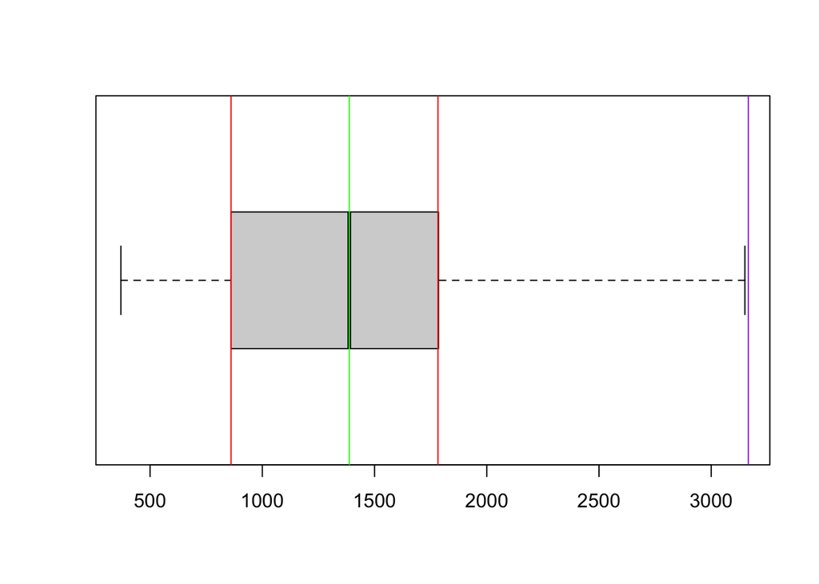

```r
boxplot(data$Sold, horizontal=T)
iqr=quantile(data$Sold)[4] - quantile(data$Sold)[2]
abline(v=median(data$Sold),col="green")
abline(v=quantile(data$Sold)[2],col="red") # 25%
abline(v=quantile(data$Sold)[4],col="red") # 75%
abline(v=quantile(data$Sold)[2]- 1.5*iqr,col="purple") # out of the plot
abline(v=quantile(data$Sold)[4]+ 1.5*iqr,col="purple")
```

**R uses the convention**

$$LT = \text{max}(\text{min}(x), Q_1 - 1.5 \times IQR)$$

and

$$UT = \text{min}(\text{max}(x), Q_3 + 1.5 \times IQR)$$

# 3 Normal Curve

## 3.1 General&Standard Normal Curve

The **General** Normal Curve has any mean and SD. It is denoted by $N(mean, Variance)$, where $Variance = SD^2$

The **Standard** Normal Curve $(Z)$ has mean $0$ and SD $1$. Short: $N(0,1)$

## 3.2 The Normal Curve formula

The **general normal curve** can be described by the formula

$$f(x) = \frac{1}{\sqrt{2\pi\sigma^2}} e^{-\frac{(x-\mu)^2}{2\sigma^2}}
\quad \text{for } x \in (-\infty, \infty)$$

where we can control the shape by $(\mu, \sigma)$:

- $\mu$ is the **mean**, or the centre of the curve.
- $\sigma$ is the **standard deviation**, or the spread of the curve.

## 3.3 Area under a normal curve

The area under any general normal curve $N(\mu, \sigma^2)$, bounded by some interval $(a, b)$, is given by

$$P(a < X < b) = \int_{a}^{b} \frac{1}{\sqrt{2\pi\sigma^2}}
e^{-\frac{(x-\mu)^2}{2\sigma^2}} \, dx$$

- The total area under the normal curve (between $a = -\infty$ and $b = \infty$) is 1.
- $X$ denotes data following a general normal curve with mean $\mu$ and standard deviation (SD) $\sigma$.
- $P(a < X < b)$ denotes the proportion of data falling into the interval $(a, b)$.

## 3.4 Area under the normal curve In R

- The `pnorm(x)` command works out the lower tail area, it gives

$$P(Z < x) = \int_{-\infty}^{x} \frac{1}{\sqrt{2\pi}}
e^{-\frac{z^2}{2}} \, dz$$

- The `pnorm(x, lower.tail=F)` works out the upper tail area, it gives

$$P(Z > x) = \int_{x}^{\infty} \frac{1}{\sqrt{2\pi}} e^{-\frac{z^2}{2}}
\, dz$$

- We also have

$$P(Z > x) = 1 - P(Z < x) \quad \text{or} \quad \text{upper tail
area} = 1 - \text{lower tail area}$$

- `pnorm(x,mean,sd)`

## 3.5 Properties of the normal curve

### 3.5.1 “68%-95%-99.7% Rule”

All normal curves satisfy the “68%-95%-99.7% rule”:

- The area 1 SD out from the mean in both directions is 0.68 (68%).
- The area 2 SDs out from the mean in both directions is 0.95 (95%).
- The area 3 SDs out from the mean in both directions is 0.997 (99.7%).

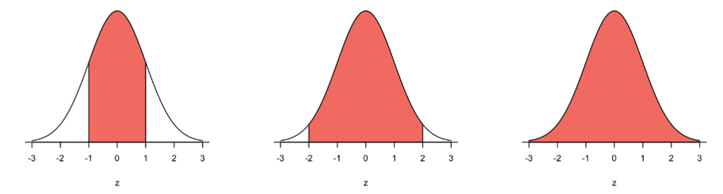

### 3.5.2 Rescaling

**Any general normal curve can be rescaled into the standard normal curve**

Consider data following a general normal curve . For any point on this normal curve, recall that the standard unit (or score) is how many standard deviations that point is above (+) or below (-) the mean.

$standard unit = \frac{data point- samplemean}{sample SD}$ or $z = \frac{x-\mu}{\sigma}$

- The standard unit give the relative location of a data point on the standard normal curve.
- The proportion under a general normal curve $P(X<a)$ **is equivalent to** the proportion under the standard normal curve $P(Z< \frac{a-\mu}{\sigma})$

### 3.5.3 The normal curve is symmetric about the mean

- If $Z$ follows the standard normal curve $N(0,1)$, then $P(Z < -a) = P(Z > a)$
- If $X$ follows a general normal curve $N(\mu,\sigma^2)$, then $P(X<\mu-a) = P(X>\mu+a)$

## 3.6 Quantiles

### 3.6.1 Calculate the quantiles of normal curves using R

**Goal: What is the quantile $Q$ such that $p%$ of the data $X$ falling below the value $Q$**:

`qnorm(x, mu, sigma)`

# 4 Correlation and linear model

## 4.1 Scatter plot & Bivariate data

### 4.1.1 Bivariate data

Bivariate data involves a pair of variables. We are interested in the relationship between the two variables. **Can one variable be used to predict the other?.**

- Formally, we have $(x_i,y_i)$ for $i=1,2,3,4...,n$
- $X$ and $Y$ can have the same role.
- $X$ and $Y$ may have different roles; for example, $X$ can be an $independent$ variable (or explanatory variable, predictor or regressor) which we use to explain or predict $Y$, the $dependenet$ variable (or response variable)

### 4.1.2 Summary bivariate data

- sample mean and sample SD of $X$ ($\overline{x}$,SD_x)
- sample mean and sample SD of $Y$ ($\overline{y}$,SD_y)
- correlation coefficient($r$)

### 4.1.3 correlation coefficient

- a numeric summary measures of how points are spread around the line
- It indicates both the sigh and the strength of the **linear association**
- It is defined as the **mean** of the **product** of the variables in **standard units**

That is

$$r = \frac{1}{n-1} \sum_{i=1}^{n} \left(\frac{x_i -
\overline{X}}{SD_{\text{sample}}(X)}\right) \left(\frac{y_i -
\overline{Y}}{SD_{\text{sample}}(Y)}\right)$$
by sample sd

or

$$r = \frac{1}{n} \sum_{i=1}^{n} \left(\frac{x_i -
\overline{X}}{SD_{\text{pop}}(X)}\right) \left(\frac{y_i -
\overline{Y}}{SD_{\text{pop}}(Y)}\right)$$
by pop sd

or

```
cor(x,y)
```

in R

### 4.1.4 Properties and Warnings

- Warning 1
  - Mistake 1 $r = 0.8$ means that 80% of the points are tightly closed around the line
  - Mistake 2 $r = 0.8$ means that 80% of the points are twice as tightly closed as $r = 0.4%$
- Warning 2
  - Outliers can overly influence the correlation coefficient
- Warning 3
  - Nonlinear association can’t be detected by the correlation coefficient
  - **We should always use correlation coefficient together with the scatter plot.**
- Warning 4
  - The same correlation coefficient can arise from very different data

## 4.2 Regression Line

**Goal: summary data with a line**

### 4.2.1 SD line (no good)

The **SD line** might look like a good candidate as it connects the point of averages $(\overline{x}, \overline{y})$ to $(\overline{x} + SD_x, \overline{y} + SD_y)$ .

This model **does not use the correlation coefficient**, so it is **insensitive to the amount of clustering around the line.**

### 4.2.2 Regression Line (Best option)

| Feature | Regression Line $y \sim x$ ($y = a + bx$) |
| --- | --- |
| Connects | $(\overline{x}, \overline{y})$ to $(\overline{x} + SD_x, \overline{y} + rSD_y)$ |
| Slope (b) | $\frac{r \cdot SD_y}{SD_x}$ |
| Intercept (a) | $\overline{y} - b\overline{x}$ |

**Optimality**: We can derive the regression line using calculus, by minimising the sum of squares of the residuals

### 4.2.3 Rgerssion Line in R

```
lm(y ~ x)

model = lm(y ~ x)

model$coeff
```

Then y = model$coeff[1] + model$coeff[2]x

```
abline(lm(y ~ x), col = "red")
```

## 4.3 Prediction

### 4.3.1 Baseline prediction

If we don’t use the information of the independent variable $x$ at all, a basic prediction of $y$ would be the **average** of y for **all** the x values in the data.

### 4.3.2 Regression line prediction

A better prediction is based on the regression line $y = slope \times x + intercept$

**Warning**

If we want to use $Y$ to predict $X$, we need to **refit** the model

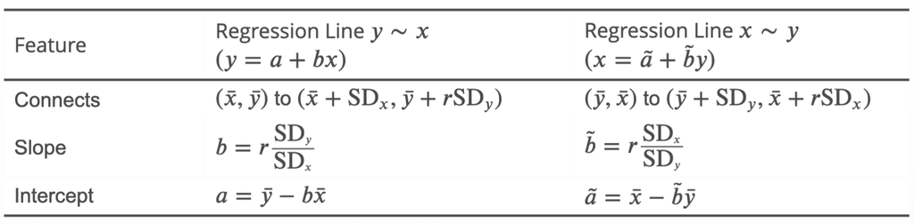

In R: `lm(y~x)` != `lm(x~y)`

## 4.4 Residuals and properties

### 4.4.1 Residuals(prediction error)

- A **residual** is the vertical distance of a point above or below the regression line
- A residual represents the error between the actual value and the prediction
- The regression line is the **best**(optimal) linear model: it provides the best fit to the data as the sum of the squared residuals is as small as it can be

### 4.4.2 Summary of Residuals

| Feature | Regression Line $y \sim x$ ( $y = a + bx$ ) |
| --- | --- |
| Connects | $(\bar{x}, \bar{y})$ to $(\bar{x} + SD_x, \bar{y} + rSD_y)$ |
| Slope (b) | $r \frac{SD_y}{SD_x}$ |
| Intercept (a) | $\bar{y} - b \bar{x}$ |
| Residual | $e_i = y_i - a - bx_i$ |

- $y = a + bx$ is the best line that minimizes the sum of squared residuals $\sum_{i=1}^n e_i^2$.
- The average residual of the regression line is zero: $\bar{e} = \frac{1}{n} \sum_{i=1}^n e_i = 0$.

## 4.5 Coefficient of determination

### 4.5.1 Idea

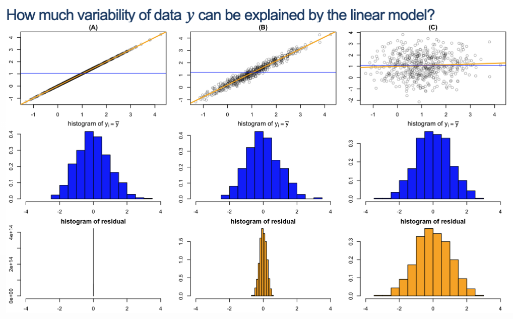

- **A**: Data for which all variation is explained, All the points fall exactly on a straight line.In this case, all (100%) of the sample variation in y can be attributed to the fact that x and y are linearly related in combination woth variation in x.
- **B**: Data for which most variation is explained. The points do not fall exantly on a line, but compared to overall **y** variability, the residuals from the regression line are small. It is reasonable to conclude in this case that much of the observed **y** variation can be attributed to the linear regression model.
- **C**: Data for which little variation is explained. There is substantial variation in the points about the regression line relative to overall **y** variation, so the linear regression model fails to explain variation in **y** by relating **y** to **x**.

### 4.5.2 SSE vs SST

**(i)** The Sum of Squared Errors (SSE) is given by:

$$\text{SSE} = \sum_{i=1}^{n} e_i^2 = \sum_{i=1}^{n} (y_i - a - bx_i)^2$$

where:

- $y_i$ is the observed value,
- $a$ is the intercept,
- $b$ is the slope, and
- $x_i$ is the predictor value.

**SSE** measures variation in y left unexplained by the regression line.

**(ii)** A quantitative measure of **the total amount of variation in observed y values** is given by the total sum of squares (sum of squared deviations about sample mean)

The Total Sum of Squares (SST) is given by:

$$\text{SST} = \sum_{i=1}^{n} (y_i - \bar{y})^2$$

where:

- $y_i$ is the observed value,
- $\bar{y}$ is the mean of the observed values,
- $n$ is the number of observations.

measures variation in left unexplained by the **baseline prediction**.

**SST $\geq$ SSE**: The regression is optimal for sum of squared errors, so SSE (regression line) cannot be worse than SST (baseline).

### 4.5.3 Coefficient of determination

The ratio $\frac{\text{SSE}}{\text{SST}}$ is the proportion of total variation that cannot be explained by the simple linear regression model, and the coefficient of determination is

$$1 - \frac{\text{SSE}}{\text{SST}} = r^2$$

which is the **squared correlation coefficient** (a number between 0 and 1) giving the proportion of observed $y$ variation explained by the model.

- The higher the value of $r^2$, the more successful is the simple linear regression model in explaining y variation
- If SSE = 0 , then $r^2 = 1$

## 4.6 Diagnostics

### 4.6.1 Residual plot

- A residual plot graphs the residuals vs $x$
- If the linear fit is appropriate for the data, it should show no pattern (random points arount 0)
- By checking the patterns of the residuals, the residual plot is a diagnostic plot to check the appropriateness of a linear model

### 4.6.2 Homoscedasticity and Heteroscedasticity

In linear models and regression analysis generally, we need to check the homogeneity of the spread of the response variable (or the residuals). We can divide the scatter plot or the residual plot into vertical strips.

- If the vertical strips on the scatter plot show equal spread in the y direction, then the data is **homoscedastic**.
  - The regression line could be used for predictions.
- If the vertical strips don’t show equal spread in the y direction, then the data is **heteroscedastic**.
  - The regression line should not be used for predictions.

# 5 Probability

## 5.1 probability models

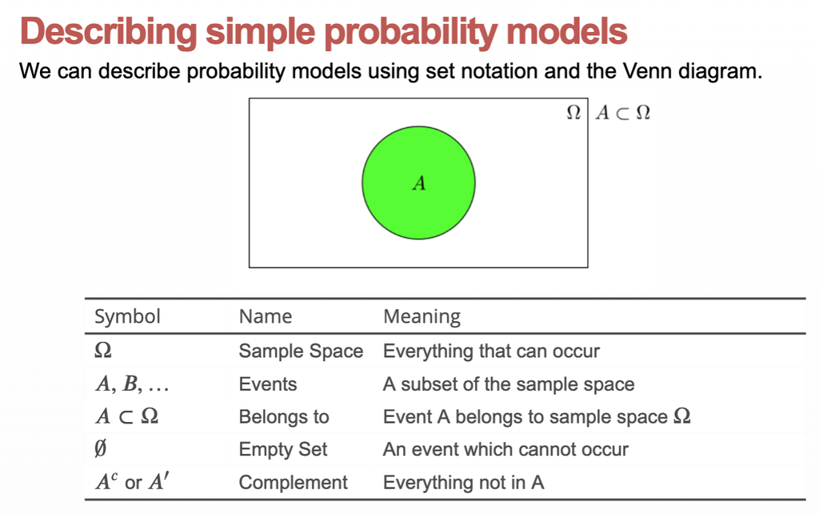

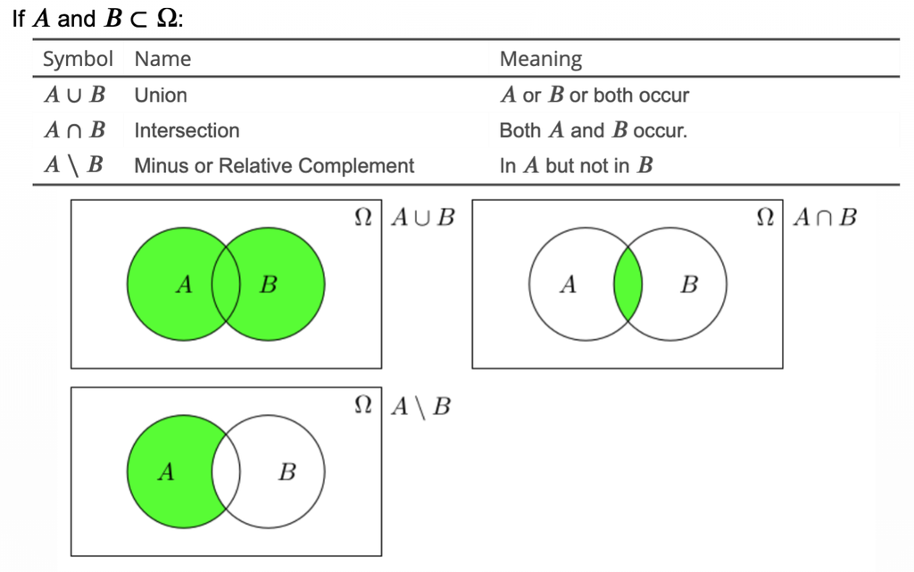

**De Morgan’s Law**

- $(A \cup B)^c = A^c \cap B^c$
- $(A \cap B)^c = A^c \cup B^c$

## 5.2 Properties

### 5.2.1 “Classical” probability”

Too easy

### 5.2.2 Probabilities are between 0 (impossible) and 1 (certain)

Ben Dan

### 5.2.3 Complement

Bu Xiang Xue Xi Zen Me Ban

### 5.2.4 Mutually exclusive

Two events $A$ and $B$ are mutually exclusive if

Two events A and B are independent if and only if
$$P( A \cap B) = P(A)P(B)$$

Difference between Mutually Exclusive and Independence

| Term | Definition |
| --- | --- |
| Mutually exclusive | the occurrence of Event B prevents Event A from occurring |
| Independence | the occurrence of Event B does not change the chance of Event A occurring |

## 5.3 Conditional probability

For events $A$ and $B \in \Omega$ where $P(B) \neq 0$, the conditional probability of $A$ given $B$ is

$$P(A|B) = \frac{P(A \cap B)}{P(B)}$$

Two events $A$ and $B$ are independent if and only if

$$P(A|B) = P(A)$$

## 5.4 Multiplication and Addition Rule

- **Multiplication rule**: The probability that A and B occur is $P(A)$ multiplied by the conditional probability

$$P(A \cap B) = P(A)P(B|A)$$

- **Addition rule**: The probability at least one of A and B occurs is $P(A)$ **plus** $P(B)$ minus the probabiliry that both events occur.

$$P(A \cup B) = P(A) + P(B) - P(A \cap B)$$

## 5.5 The prosecutor’s fallacy

The prosecutor’s fallacy is a mistake in statistical thinking, whereby it is assumed that the probability of a random match is equal to the probability that the defendant is innocent.

认为随机匹配的概率等于被告人无罪的概率。

# 6 Counting and Simulating Chance

Use R and simulate throwing 2 dice times $x$ and record the findings.

```r
set.seed(23)
totals = sample(1:6, 1000, rep = T) + sample(1:6, 1000, rep=T)
table(totals)
```

```
## totals
##   2   3   4   5   6   7   8   9  10  11  12
##  27  55  79 124 144 168 138 109  88  45  23
```

## 6.2 Box model

Many counting and probability problems can be reduced to a box model. In a box model, there are tickets in a box, and we draw tickets from the box.

## 6.3 Methods

### 6.3.1 Write a list manually

ez

### 6.3.2 Summarise in a tree diagram

ez

### 6.3.3 Simulate in R

- using a function

```r
gameA <- function(){
  rolls = sample(1:6,size = 4,replace = TRUE)
  condition = sum(rolls == 1) > 0
  return(condition)
}
simsA = replicate(100000,gameA())
sum(simsA)/length(simsA)
```

```
## [1] 0.51547
```

## 6.4 Multiplication Principle of Counting

If a task can be performed in $n_1$ ways, and for each of these ways, a second task can be performed in $n_2$ ways, then the two tasks can be performed together in a total of $n_1 \times n_2$ ways. If there are tasks in such a sequence, then k tasks can be performed together in a total of $n_1 \times n_2 \times n_3 ... \times n_k$ ways.

# 7 The box model

## 7.1 Definition

The box model is a very **simple** statistical model for representing a population. The box model can be thought of as:

- A collection of N objects, e.g. tickets,balls is imagined “in a box”
- Each object bears a number
- A **random sample** of a certain number **n** of the objects is taken
- The sampling may be **with** or **without** replacement

## 7.2 Random samples and Random draws

- **Random Sample:** Consider all possible ways of selecting objects from the box. A **random sample** is when each possible of these selection is equally likely.
- A **random draw** is a random sample with $n=1$
  - is a single draw is taken, theneach object in the box has an equal chance of being picked

## 7.3 Using `outer`

The R function `outer()` forms a two-way array by applying an operation to each pair of elements from two vectors:

```r
bx = c(1, 2, 3)
by = c(2, 4)
bs = outer(bx, by, "+")
bs
```

```
##      [,1] [,2]
## [1,]    3    5
## [2,]    4    6
## [3,]    5    7
```

```r
mean(bs)
```

```
## [1] 5
```

## 7.4 Expected Value and Standard Error of Sum

- expected value of sum is sum of expected value
- squared SE of the sum is the sum of squared SEs

## 7.5 Computing Formula for SD

$SD^2 = \frac{1}{M} \sum_{i=1}^{M} (x_i - \bar{x})^2 = \left( \frac{1}{M} \sum_{i=1}^{M} x_i^2 \right) - \bar{x}^2$

That is : the **mean square minus the square of the mean** (This is the population sd)

## 7.6 Random samples with replacement of size 𝑛 = 2

When we have a single box, but take 2 random draws with replacement.

- This means each of the $N^2$ possible pairs $(x_1,x_1), (x_1,x_n)...$ is equally like.

In this case, we have:

- $E(X) = E(Y)$
- $SE(X) = SE(Y)$

## 7.7 Sum&Averages of random samples of size $n$

### 7.7.1 The Sum $S$

- Suppose we have a box $X$ such that $E(X_1) = \mu$ and $SE(X_1) = \sigma$
- Expected value of sum is sum of expected values: $E(S) = \mu n$
- $SE(S) = \sqrt{n} \sigma$

### 7.7.2 The Average $\bar{X}$

- $E(\bar{X}) = \mu$
- $SE(\bar{X}) = \frac{\sigma}{\sqrt{n}}$

# 8 Central Limit Theorem

## 8.1 Definition

Given $S = X_1 + \cdots + X_n$, where a random sample of size $n$ is taken from a population with mean $\mu$ and standard deviation $\sigma$, for large $n$, we have:

$$P(S \leq s) = P\left( \frac{S - n\mu}{\sigma\sqrt{n}} \leq \frac{s -
n\mu}{\sigma\sqrt{n}} \right) \approx \Phi\left( \frac{s -
n\mu}{\sigma\sqrt{n}} \right)$$

where $\Phi(z)$ represents the cumulative distribution function of the standard normal distribution.

## 8.2 Understanding

It states that when we take samples from a population, regardless of the shape of the population distribution, as long as the sample size is large enough, the distribution of the sample sum or sample mean will approach a normal distribution.

# 9 Unknown Properties

## 9.1 The 0-1 box

- Let $p$ denotes the proportion of $1$s in the box, and $N$ the number of tickets.
- $\mu$ and $\sigma$ only depend on $p$ now
- the mean of the box $\mu = p$
- the SD of the box is $\sigma = \sqrt{p(1-p)}$

## 9.2 Prediction intervals

### 9.2.1 Question&Intro

- A 100 $\gamma$% (two-sideed) prediction interval for the sample sum $S$ is an interval $[a,b]$ in which there is a 100 $\gamma$% chance that $S$ lands in $[a,b]$:
  $$P(a \leq S \leq b) = \gamma$$
- A 100 $\gamma$% (two-sideed) prediction interval for the sample average $\bar{X}$ is an interval $[a,b]$ in which there is a 100 $\gamma$% chance that $\bar{X}$ lands in $[a,b]$:
  $$P(a \leq \bar{X} \leq b) = \gamma$$

### 9.2.2 Calculate a,b

- Mean

$$P(a \leq \bar{X} \leq b) = P \left( \frac{a - E(\bar{X})}{SE(\bar{X})}
\leq \frac{\bar{X} - E(\bar{X})}{SE(\bar{X})} \leq \frac{b -
E(\bar{X})}{SE(\bar{X})} \right)$$

$CI = E(\bar{X}) \pm z^* SE(\bar{X})$

$$\left[ p - z^* \cdot \sqrt{\frac{p(1 -
p)}{n}}, \, p + z^* \cdot \sqrt{\frac{p(1 - p)}{n}} \right]$$
- Sum

$$P(a \leq S \leq b) = P \left( \frac{a - E(S)}{SE(S)} \leq \frac{\bar{X}
- E(S)}{SE(S)} \leq \frac{b - E(S)}{SE(S)} \right)$$
$$CI = E(S) \pm z^*
SE(S)$$

$$\left[ np - z^* \cdot \sqrt{np(1 - p)},
\, np + z^* \cdot \sqrt{np(1 - p)} \right]$$

### 9.2.3 Size of prediction intervals

- For a binary box, the **variability** in the sample proportion gets smaller as the in the box gets further from 0.5.
- This is precisely reflected in $SE(\bar{X}) = \sqrt{\frac{p(1-p)}{n}}$

## 9.3 Confidence intervals

```r
library(binom)
binom.confint(14, 49, conf.level = 0.99, method = "wilson")
```

```
##   method  x  n      mean     lower     upper
## 1 wilson 14 49 0.2857143 0.1531828 0.4693562
```